# Introduction data handling and graphical representation

Katharina Imkeller

15. June 2020

# Data wrangling with dplyr

dplyr is an R package that allows easy manipulation of data tables. A set of commonly used dplyr commands can be found on the following summary: dplyr cheatsheet.

The dplyr functions are:

- filter() picks cases based on their values.
- summarise() reduces multiple values down to a single summary.
- arrange() changes the ordering of the rows.
- mutate() adds new variables that are functions of existing variables
- select() picks variables based on their names.

The following script illustrate how to use these functions on a dataset containing information on different types of iris plants. This dataset is just for illustration purposes, because it is especially well suited to understand how dplyr is working. A similar introduction using a dataset about Starwars characters can also be found here: https://dplyr.tidyverse.org/.

Later on in the tutorial you will perform the same type of manipulations on a dataset of antibody reactivity data.

```r
library(dplyr)
```

## Filtering data tables

filter() picks cases (rows) based on their values. In all following example, the DT::datatable() function is there to display the tables in a readable way.

```r
DT::datatable(
filter(iris, Species == "versicolor")
)
```

|  | Sepal.Length | Sepal.Width | Petal.Length | Petal.Width | Species |
| --- | --- | --- | --- | --- | --- |
| 1 | 7 | 3.2 | 4.7 | 1.4 | versicolor |
| 2 | 6.4 | 3.2 | 4.5 | 1.5 | versicolor |
| 3 | 6.9 | 3.1 | 4.9 | 1.5 | versicolor |
| 4 | 5.5 | 2.3 | 4 | 1.3 | versicolor |
| 5 | 6.5 | 2.8 | 4.6 | 1.5 | versicolor |
| 6 | 5.7 | 2.8 | 4.5 | 1.3 | versicolor |
| 7 | 6.3 | 3.3 | 4.7 | 1.6 | versicolor |
| 8 | 4.9 | 2.4 | 3.3 | 1 | versicolor |
| 9 | 6.6 | 2.9 | 4.6 | 1.3 | versicolor |
| 10 | 5.2 | 2.7 | 3.9 | 1.4 | versicolor |

[output cut: 40 more lines]

Usage of the %>% pipe:

```r
DT::datatable(
iris %>%
    filter(Species == "versicolor")
)
```

|  | Sepal.Length | Sepal.Width | Petal.Length | Petal.Width | Species |
| --- | --- | --- | --- | --- | --- |
| 1 | 7 | 3.2 | 4.7 | 1.4 | versicolor |
| 2 | 6.4 | 3.2 | 4.5 | 1.5 | versicolor |
| 3 | 6.9 | 3.1 | 4.9 | 1.5 | versicolor |
| 4 | 5.5 | 2.3 | 4 | 1.3 | versicolor |
| 5 | 6.5 | 2.8 | 4.6 | 1.5 | versicolor |
| 6 | 5.7 | 2.8 | 4.5 | 1.3 | versicolor |
| 7 | 6.3 | 3.3 | 4.7 | 1.6 | versicolor |
| 8 | 4.9 | 2.4 | 3.3 | 1 | versicolor |
| 9 | 6.6 | 2.9 | 4.6 | 1.3 | versicolor |
| 10 | 5.2 | 2.7 | 3.9 | 1.4 | versicolor |

[output cut: 40 more lines]

Filters can be combined:

```r
DT::datatable(
iris %>%
    # AND
    filter(Species == "versicolor" & Petal.Width < 1.2)
)
```

|  | Sepal.Length | Sepal.Width | Petal.Length | Petal.Width | Species |
| --- | --- | --- | --- | --- | --- |
| 1 | 4.9 | 2.4 | 3.3 | 1 | versicolor |
| 2 | 5 | 2 | 3.5 | 1 | versicolor |
| 3 | 6 | 2.2 | 4 | 1 | versicolor |
| 4 | 5.8 | 2.7 | 4.1 | 1 | versicolor |
| 5 | 5.6 | 2.5 | 3.9 | 1.1 | versicolor |
| 6 | 5.7 | 2.6 | 3.5 | 1 | versicolor |
| 7 | 5.5 | 2.4 | 3.8 | 1.1 | versicolor |
| 8 | 5.5 | 2.4 | 3.7 | 1 | versicolor |
| 9 | 5 | 2.3 | 3.3 | 1 | versicolor |
| 10 | 5.1 | 2.5 | 3 | 1.1 | versicolor |

```r
DT::datatable(
iris %>%
    #  OR
    filter(Species == "versicolor" | Petal.Width < 1.2)
)
```

|  | Sepal.Length | Sepal.Width | Petal.Length | Petal.Width | Species |
| --- | --- | --- | --- | --- | --- |
| 1 | 5.1 | 3.5 | 1.4 | 0.2 | setosa |
| 2 | 4.9 | 3 | 1.4 | 0.2 | setosa |
| 3 | 4.7 | 3.2 | 1.3 | 0.2 | setosa |
| 4 | 4.6 | 3.1 | 1.5 | 0.2 | setosa |
| 5 | 5 | 3.6 | 1.4 | 0.2 | setosa |
| 6 | 5.4 | 3.9 | 1.7 | 0.4 | setosa |
| 7 | 4.6 | 3.4 | 1.4 | 0.3 | setosa |
| 8 | 5 | 3.4 | 1.5 | 0.2 | setosa |
| 9 | 4.4 | 2.9 | 1.4 | 0.2 | setosa |
| 10 | 4.9 | 3.1 | 1.5 | 0.1 | setosa |

[output cut: 90 more lines]

# Summarizing and grouping

summarise() reduces multiple values down to a single summary

```r
DT::datatable(
iris %>%
  summarise(
    n = n(),
    meanSW = mean(Sepal.Width, na.rm = TRUE)
  )
)
```

|  | n | meanSW |
| --- | --- | --- |
| 1 | 150 | 3.05733333333333 |

```r
DT::datatable(
iris %>%
  group_by(Species) %>%
    summarise(
    n = n(),
    meanSW = mean(Sepal.Width, na.rm = TRUE)
  )
)
```

|  | Species | n | meanSW |
| --- | --- | --- | --- |
| 1 | setosa | 50 | 3.428 |
| 2 | versicolor | 50 | 2.77 |
| 3 | virginica | 50 | 2.974 |

arrange() changes the ordering of the rows

```r
DT::datatable(
iris %>%
  group_by(Species) %>%
    summarise(
    n = n(),
    meanSW = mean(Sepal.Width, na.rm = TRUE)
  ) %>%
    arrange(meanSW)
)
```

|  | Species | n | meanSW |
| --- | --- | --- | --- |
| 1 | versicolor | 50 | 2.77 |
| 2 | virginica | 50 | 2.974 |
| 3 | setosa | 50 | 3.428 |

## Selecting columns

select() picks variables based on their names.

```r
DT::datatable(
iris %>%
  select(Sepal.Width, Species)
)
```

|  | Sepal.Width | Species |
| --- | --- | --- |
| 1 | 3.5 | setosa |
| 2 | 3 | setosa |
| 3 | 3.2 | setosa |
| 4 | 3.1 | setosa |
| 5 | 3.6 | setosa |
| 6 | 3.9 | setosa |
| 7 | 3.4 | setosa |
| 8 | 3.4 | setosa |
| 9 | 2.9 | setosa |
| 10 | 3.1 | setosa |

[output cut: 140 more lines]

```r
DT::datatable(
iris %>%
  select(Species, ends_with("Width"))
)
```

|  | Species | Sepal.Width | Petal.Width |
| --- | --- | --- | --- |
| 1 | setosa | 3.5 | 0.2 |
| 2 | setosa | 3 | 0.2 |
| 3 | setosa | 3.2 | 0.2 |
| 4 | setosa | 3.1 | 0.2 |
| 5 | setosa | 3.6 | 0.2 |
| 6 | setosa | 3.9 | 0.4 |
| 7 | setosa | 3.4 | 0.3 |
| 8 | setosa | 3.4 | 0.2 |
| 9 | setosa | 2.9 | 0.2 |
| 10 | setosa | 3.1 | 0.1 |

[output cut: 140 more lines]

## Adding columns (mutating the table)

mutate() adds new variables that are functions of existing variables

```r
DT::datatable(
iris %>%
  mutate(Sepal.Ratio = Sepal.Width/Sepal.Length)
)
```

|  | Sepal.Length | Sepal.Width | Petal.Length | Petal.Width | Species | Sepal.Ratio |
| --- | --- | --- | --- | --- | --- | --- |
| 1 | 5.1 | 3.5 | 1.4 | 0.2 | setosa | 0.686274509803922 |
| 2 | 4.9 | 3 | 1.4 | 0.2 | setosa | 0.612244897959184 |
| 3 | 4.7 | 3.2 | 1.3 | 0.2 | setosa | 0.680851063829787 |
| 4 | 4.6 | 3.1 | 1.5 | 0.2 | setosa | 0.673913043478261 |
| 5 | 5 | 3.6 | 1.4 | 0.2 | setosa | 0.72 |
| 6 | 5.4 | 3.9 | 1.7 | 0.4 | setosa | 0.722222222222222 |
| 7 | 4.6 | 3.4 | 1.4 | 0.3 | setosa | 0.739130434782609 |
| 8 | 5 | 3.4 | 1.5 | 0.2 | setosa | 0.68 |
| 9 | 4.4 | 2.9 | 1.4 | 0.2 | setosa | 0.659090909090909 |
| 10 | 4.9 | 3.1 | 1.5 | 0.1 | setosa | 0.63265306122449 |

[output cut: 140 more lines]

# Generating graphics using ggplot2

ggplot2 is an R package for generating graphical representations of your data. A set of commonly used dplyr commands can be found on the following summary: ggplot2 cheatsheet.

```r
library(ggplot2)
```

A ggplot2 command consists of following elements:

- a ggplot() function that has the dataset (here iris) as first argument
- an aesthetic mapping aes(), where you define the columns of the dataset that should be used as x, y, color, size…
- a layer, where you define what type of plotting functions should be used (layers can be overlayed)

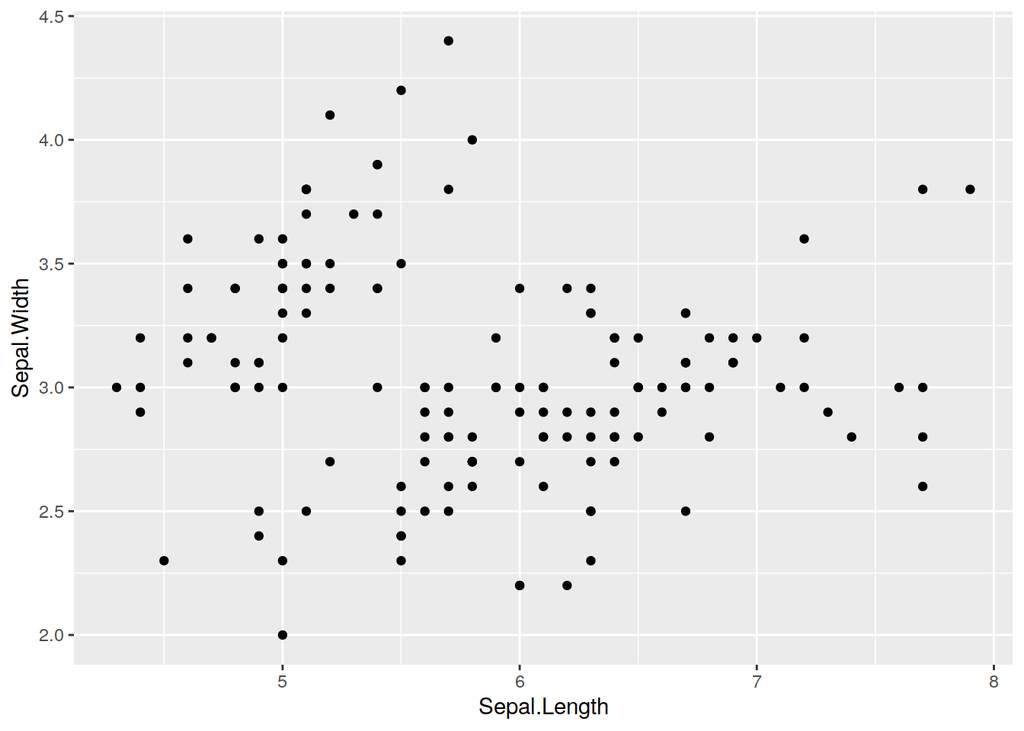

```r
ggplot(iris, aes(x = Sepal.Length, y = Sepal.Width)) +
    geom_point()
```

The dots can be colored according to iris species:

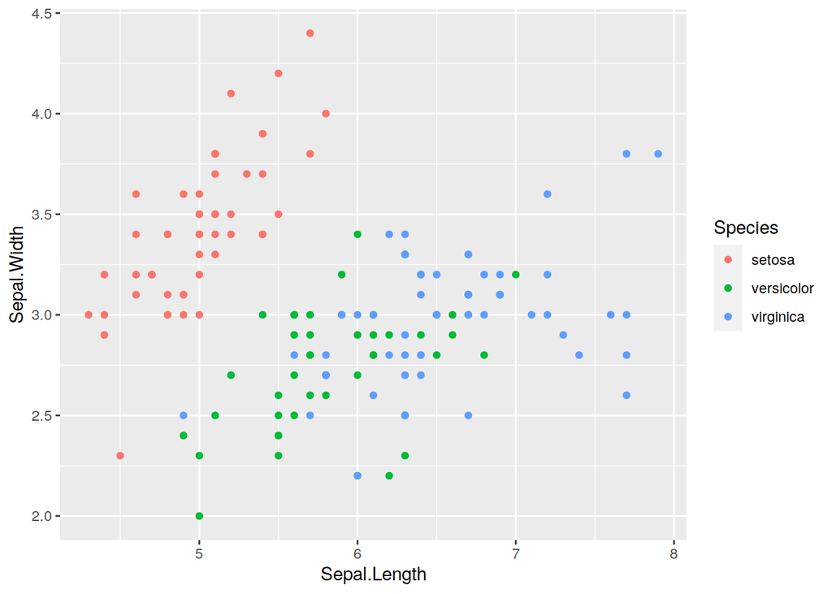

```r
ggplot(iris, aes(x = Sepal.Length, y = Sepal.Width, color=Species)) +
    geom_point()
```

A faceting specification (e.g. facet_wrap()) can be used to split the data into several plots:

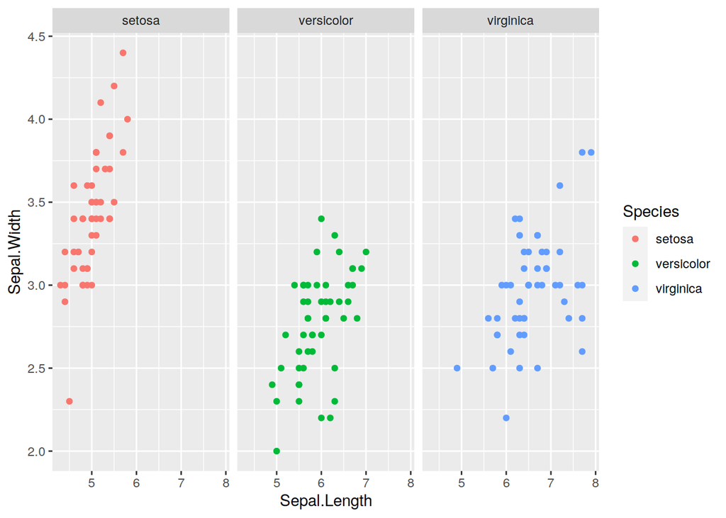

```r
ggplot(iris, aes(x = Sepal.Length, y = Sepal.Width, color=Species)) +
    geom_point() +
    facet_wrap(~Species)
```

The data can also be summarized into box-plots, by using the Species on the x axis:

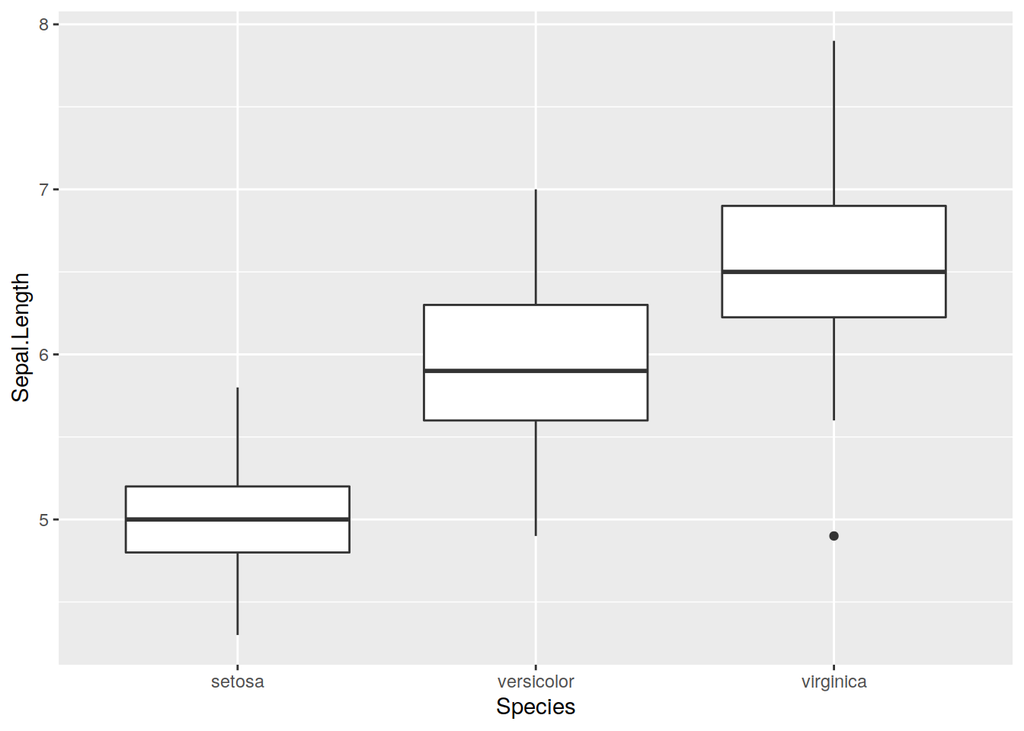

```r
ggplot(iris, aes(x = Species, y = Sepal.Length)) +
    geom_boxplot()
```

Overlaying dot-plots on top of the box-plot:

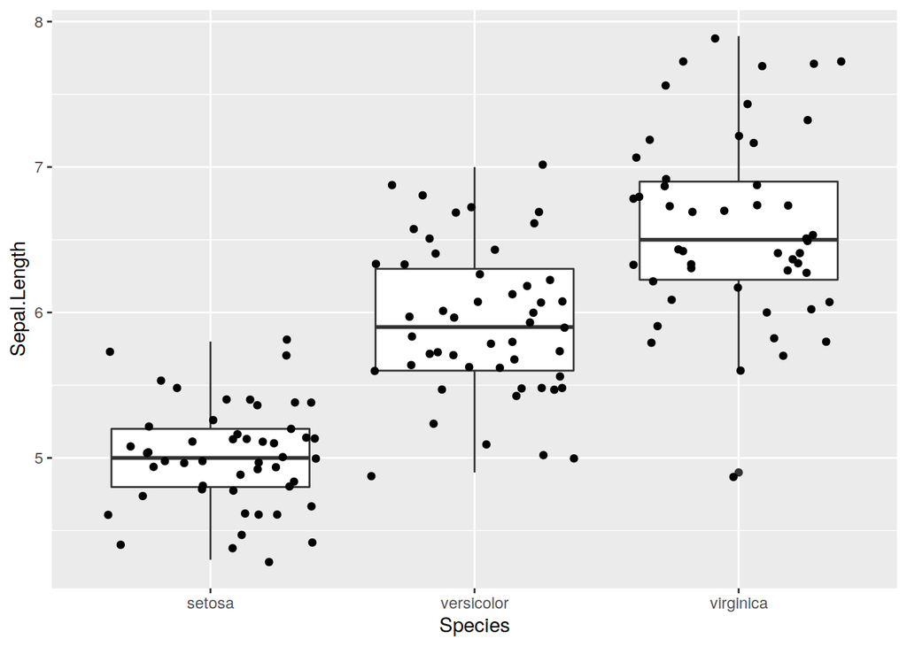

```r
ggplot(iris, aes(x = Species, y = Sepal.Length)) +
    geom_boxplot() +
    geom_jitter()
```